# Pharmaceutical Spending and The Great Recession

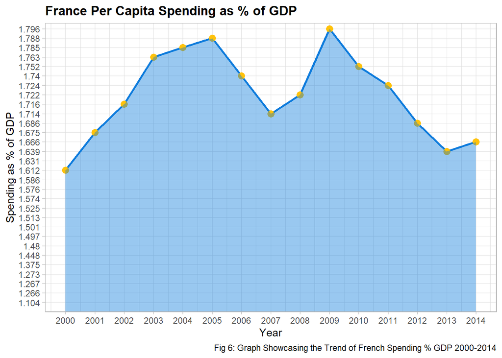

```r
#French Trend of Spending Percent of GDP (2000-2015)

frenchspending <- drug_spending %>%
  filter(LOCATION == "FRA") %>%
  ggplot(aes(x = TIME, y = as.factor(PC_GDP), group = 1)) + #for some reason i needed to specify group=1 bc the limited obs wouldnt show up
  geom_line(color = "#0C7BDC", size = 1) +
  geom_point(color = "#FFC20A", size = 3) +
  geom_area(fill = "#0C7BDC", alpha = .42) +
  xlab("Year") +
  ylab("Spending as % of GDP") +
  ggtitle("France Per Capita Spending as % of GDP") +
  theme_light() +
  theme(plot.title = element_text(face = "bold")) +
  scale_x_continuous(limits = c(2000, 2014), breaks = seq(2000, 2014, 1))+
  labs(caption = " Fig 6: Graph Showcasing the Trend of French Spending % GDP 2000-2014")

print(frenchspending)
```

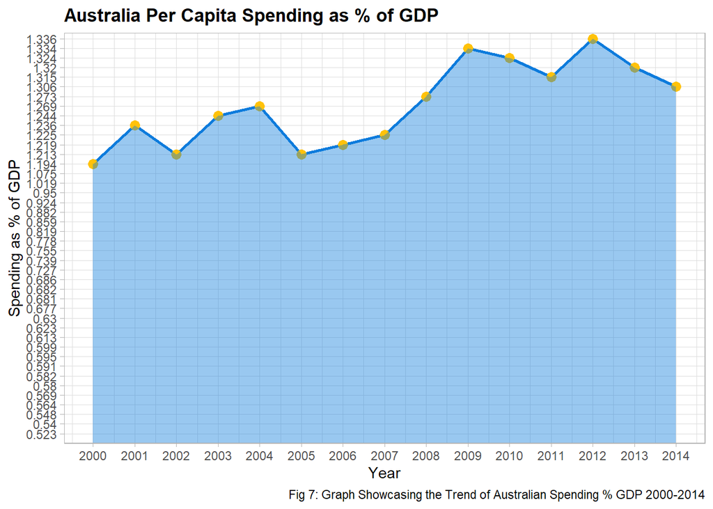

```r
#Australian Trend of Spending Percent of GDP (2000-2015)

australianspending <- drug_spending %>%
  filter(LOCATION == "AUS") %>%
  ggplot(aes(x = TIME, y = as.factor(PC_GDP), group = 1)) + #for some reason i needed to specify group=1 bc the limited obs wouldnt show up
  geom_line(color = "#0C7BDC", size = 1) +
  geom_point(color = "#FFC20A", size = 3) +
  geom_area(fill = "#0C7BDC", alpha = .42) +
  xlab("Year") +
  ylab("Spending as % of GDP") +
  ggtitle("Australia Per Capita Spending as % of GDP") +
  theme_light() +
  theme(plot.title = element_text(face = "bold")) +
  scale_x_continuous(limits = c(2000, 2014), breaks = seq(2000, 2014, 1))+
  labs(caption = " Fig 7: Graph Showcasing the Trend of Australian Spending % GDP 2000-2014")
print(australianspending)
```

# References

**Works Cited**

Carroll, Linda. “More than a third of U.S. healthcare costs go to bureaucracy.” Reuters, Reuters, 6 January 2020, https://www.reuters.com/article/us-health-costs-administration/more-than-a-third-of-u-s-healthcare-costs-go-to-bureaucracy-idUSKBN1Z5261. Accessed March 2023. Chill Lofi Beats. “Chill Lofi Beats 🌸 [chill lo-fi hip hop beats].” YouTube, Chill Lofi Beats, https://www.youtube.com/watch?v=d5aL5eP7SrI&ab_channel=LofiZone. Accessed 17 March 2023. core. “Pharmaceutical Drug Spending by countries - Dataset.” DataHub.io, OECD, https://datahub.io/core/pharmaceutical-drug-spending#readme. Accessed 17 March 2023. Malcom-White, Emily. “Intro to Data Science HWs.” 2023, https://middlebury.instructure.com/courses/11864/assignments. Accessed 2023. Merle, Renae. “A guide to the financial crisis — 10 years later.” The Washington Post, 10 September 2018, https://www.washingtonpost.com/business/economy/a-guide-to-the-financial-crisis--10-years-later/2018/09/10/114b76ba-af10-11e8-a20b-5f4f84429666_story.html. Accessed March 2023. M.S. Raghavendra, John R. Raj, A. Seetharaman. A study of decrease in R&D spending in the pharmaceutical industry during post-recession. International Journal of Academic Research Part B; 2012; 4(5), 29-47. DOI: 10.7813.2075-4124.2012/4-5/B.6 Nichols, David. “Coloring for Colorblindness.” https://davidmathlogic.com/colorblind/#%23FFC20A-%230C7BDC. Accessed 17 March 2023. Vogler S, Zimmermann N, Leopold C, de Joncheere K. Pharmaceutical policies in European countries in response to the global financial crisis. South Med Rev. 2011 Dec;4(2):69-79. doi: 10.5655/smr.v4i2.1004. Epub 2011 Dec 2. PMID: 23093885; PMCID: PMC3471176. Wei, Dr. Ying. “Colors in R.” Colors in R, Department of Biostatistics, http://www.stat.columbia.edu/~tzheng/files/Rcolor.pdf. Accessed 17 March 2023. Wikipedia. “OECD Nations in 2008 in Blue.” Wikipedia, 2008, https://upload.wikimedia.org/wikipedia/commons/2/26/OECD_Countries_Blue.png. Accessed March 2023.